# Experiment 3: Dichotic Listening Analyses

Owen Morgan

June 25, 2024

## Demographics

Demographics for all included participants.

Demographics

Summary

| N | Age (years) | Education (years) | Sex (M/F/O) | EHI |
| --- | --- | --- | --- | --- |
| 734 | 29.67 (5.84) | 14.65 (2.5) | 416/305/13 | -3.51 (79.05) |

| Handedness | N | Age (years) | Education (years) | Sex (M/F/O) | EHI |
| --- | --- | --- | --- | --- | --- |
| Left | 342 | 29.25 (5.7) | 14.9 (2.68) | 183/153/6 | -80.04 (19.25) |
| Mixed | 99 | 28.6 (6) | 14.72 (2.35) | 45/51/3 | -0.51 (28.06) |
| Right | 293 | 30.53 (5.85) | 14.33 (2.31) | 188/101/4 | 84.81 (17.3) |

Left: (EHI <= -40) | Mixed: (-40 < EHI < 40) | Right: (EHI >= 40)

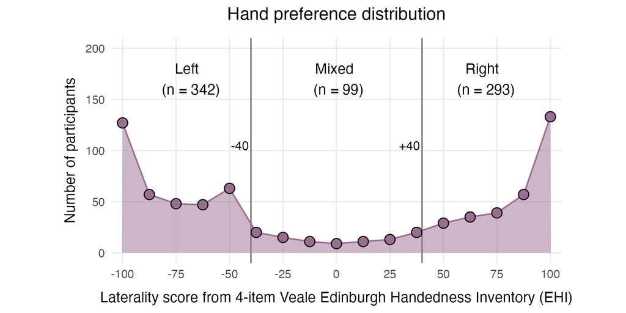

## DL ~ EHI (cont.) (primary)

Does EHI predict language laterality? (Analyses comparable to Packheiser et al., 2020)

### Stats

#### Model: DL (continuous) ~ EHI

Does handedness correlate with DL?

Correlation (rho) between EHI and language laterality (DL ~ ehi)

| estimate | statistic | p.value | parameter | conf.low | conf.high | method | alternative |
| --- | --- | --- | --- | --- | --- | --- | --- |
| 0.141 | 3.855 | .0001 | 732 | 0.069 | 0.211 | Pearson's product-moment correlation | two.sided |

Model: DL ~ ehi

| ehi | ehi.trend<sup>1</sup> | std.error | df | conf.low | conf.high | statistic | p.value |
| --- | --- | --- | --- | --- | --- | --- | --- |
| −3.508 | 0.063 | 0.016 | 732 | 0.031 | 0.095 | 3.855 | .0001 |

<sup>1</sup> Change in DL units (-100 to 100) per EHI unit (-100 to 100). Multiply by 200 to estimate the difference between strong left and right handers

When limiting analysis to participants who clicked with their right hand?

Correlation (rho) between EHI and language laterality (DL ~ ehi; right clickers)

| estimate | statistic | p.value | parameter | conf.low | conf.high | method | alternative |
| --- | --- | --- | --- | --- | --- | --- | --- |
| 0.139 | 3.169 | .002 | 511 | 0.053 | 0.223 | Pearson's product-moment correlation | two.sided |

Model: DL ~ ehi (right clickers)

| ehi | ehi.trend<sup>1</sup> | std.error | df | conf.low | conf.high | statistic | p.value |
| --- | --- | --- | --- | --- | --- | --- | --- |
| 14.62 | 0.061 | 0.019 | 511 | 0.023 | 0.098 | 3.169 | .002 |

<sup>1</sup> Change in DL units (-100 to 100) per EHI unit (-100 to 100). Multiply by 200 to estimate the difference between strong left and right handers

#### Model: DL (continuous) ~ clickhand

Does clickhand correlate with DL?

Correlation (rho) between clickhands and language laterality (DL ~ clickhand)

| estimate | statistic | p.value | parameter | conf.low | conf.high | method | alternative |
| --- | --- | --- | --- | --- | --- | --- | --- |
| 0.128 | 3.491 | .0005 | 732 | 0.056 | 0.199 | Pearson's product-moment correlation | two.sided |

Model: DL ~ ehi

| clickhand | clickhand.trend<sup>1</sup> | std.error | df | conf.low | conf.high | statistic | p.value |
| --- | --- | --- | --- | --- | --- | --- | --- |
| 60.286 | 0.064 | 0.018 | 732 | 0.028 | 0.101 | 3.491 | .0005 |

<sup>1</sup> Change in DL units (-100 to 100) per clickhand unit (-100 to 100). Multiply by 200 to estimate the difference between strong left and right clickers

#### Model: clickhand ~ ehi

Does handedness predict clickhand?

Correlation (rho) between clickhand and handedness (clickhand ~ ehi)

| estimate | statistic | p.value | parameter | conf.low | conf.high | method | alternative |
| --- | --- | --- | --- | --- | --- | --- | --- |
| 0.377 | 11.022 | <.0001 | 732 | 0.313 | 0.438 | Pearson's product-moment correlation | two.sided |

Model: DL ~ ehi

| ehi | ehi.trend<sup>1</sup> | std.error | df | conf.low | conf.high | statistic | p.value |
| --- | --- | --- | --- | --- | --- | --- | --- |
| −3.508 | 0.333 | 0.03 | 732 | 0.274 | 0.392 | 11.022 | <.0001 |

<sup>1</sup> Change in clickhand units (-100 to 100) per EHI unit (-100 to 100). Multiply by 200 to estimate the difference between strong left and right handers

#### Model: DL (continuous) ~ EHI + clickhand

Does EHI predict DL, even when controlling for clickhand?

Partial correlation (rho) between DL and ehi (DL ~ ehi * clickhand)

| statistic<sup>1</sup> | n | gp | p.value | estimate | LCL | UCL | alternative | method | data.name |
| --- | --- | --- | --- | --- | --- | --- | --- | --- | --- |
| 2.745 | 734 | 1 | .006 | 0.101 | 0.029 | 0.172 | true partial correlation is not equal to 0 | Partial correlation (pearson) | cor_data$DL_lat and cor_data$ehi; controlling: cor_data$clickhand |

<sup>1</sup> t-statistic

Model: DL ~ ehi + clickhand

| ehi | ehi.trend<sup>1</sup> | std.error | df | conf.low | conf.high | statistic | p.value |
| --- | --- | --- | --- | --- | --- | --- | --- |
| −3.508 | 0.048 | 0.018 | 731 | 0.014 | 0.082 | 2.745 | .006 |

<sup>1</sup> Change in DL units (-100 to 100) per EHI unit (-100 to 100). Multiply by 200 to estimate the difference between strong left and right handers

Is the model with clickhand better than the one without? (Could clickhand drive or inflate the effect of handedness on DL?)

Does clickhand predict language laterality, over and above EHI?<sup>1</sup>

ANOVA: compare models with vs. without interaction term<sup>1</sup>

| Res.Df | RSS | Df | Sum of Sq | F | p.value<sup>2</sup> |
| --- | --- | --- | --- | --- | --- |
| 731 | 881,116.462 | - | - | - | - |
| 732 | 887,012.684 | −1 | −5,896.222 | 4.892 | .027 |

<sup>1</sup> Model: DL (cont.) ~ EHI + clickhand  
<sup>2</sup> F-test (two-sided? https://daniellakens.blogspot.com/2016/04/one-sided-f-tests-and-halving-p-values.html)

Model: DL ~ ehi + clickhand

| clickhand | clickhand.trend<sup>1</sup> | std.error | df | conf.low | conf.high | statistic | p.value |
| --- | --- | --- | --- | --- | --- | --- | --- |
| 60.286 | 0.044 | 0.02 | 731 | 0.005 | 0.083 | 2.212 | .027 |

<sup>1</sup> Change in DL units (-100 to 100) per clickhand unit (-100 to 100). Multiply by 200 to estimate the difference between strong left and right handers

#### Model: DL (continuous) ~ EHI * clickhand

ehi emmean SE df lower.CL upper.CL -3.51 16.4 1.45 730 13.5 19.2

Confidence level used: 0.95

Model: DL ~ ehi * clickhand

| term | estimate<sup>1</sup> | std.error | statistic | p.value |
| --- | --- | --- | --- | --- |
| (Intercept) | 12.824 | 2.538 | 5.054 | <.0001 |
| ehi | 0.024 | 0.032 | 0.743 | .458 |
| clickhand | 0.061 | 0.027 | 2.255 | .024 |
| ehi:clickhand | 0 | 0 | 0.932 | .352 |

<sup>1</sup> Change in DL units (-100 to 100) per EHI unit (-100 to 100). Multiply by 200 to estimate the difference between strong left and right handers

### Plots

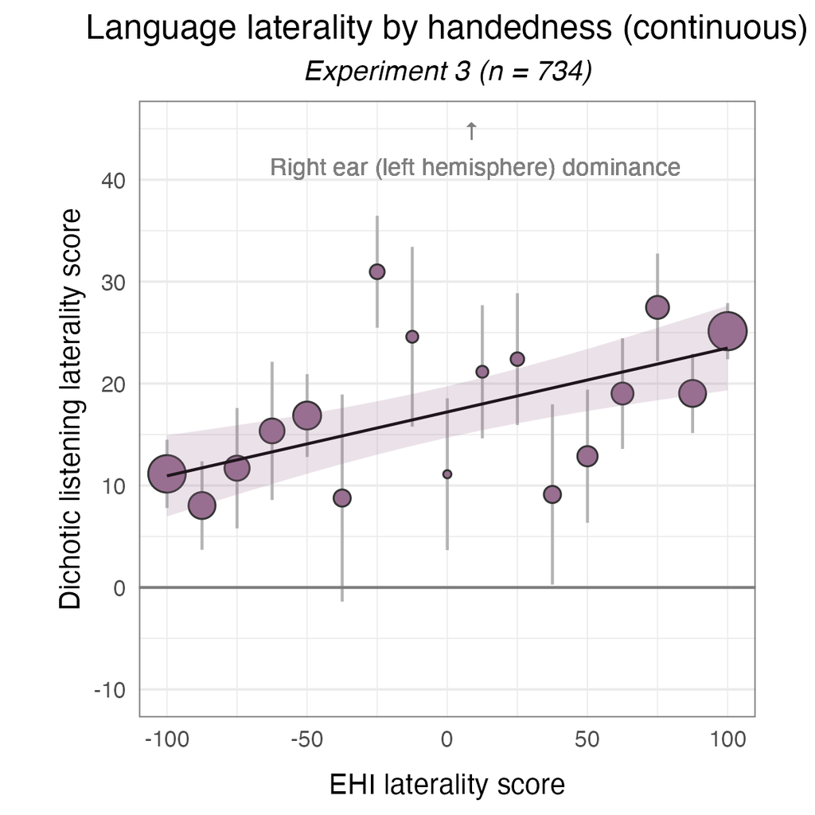

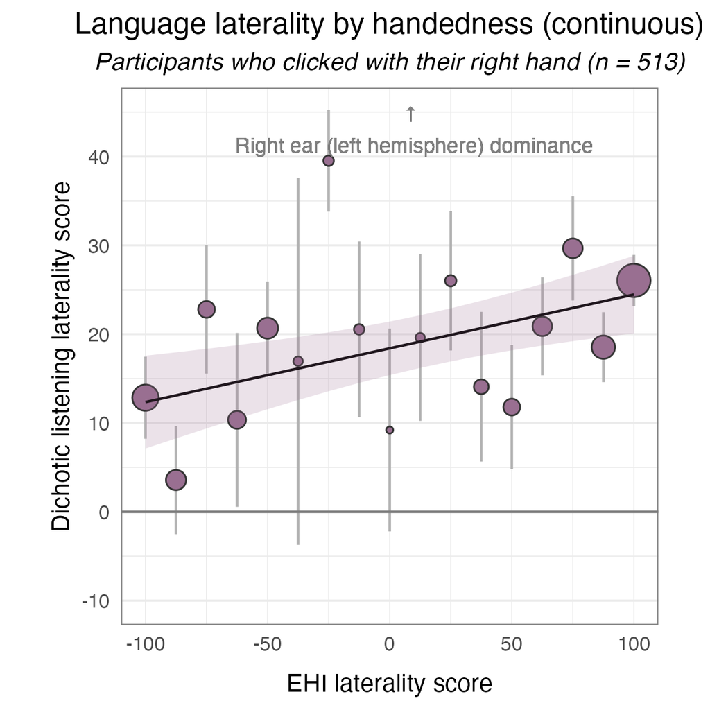

## DL (cont.) ~ handedness (cat.) (primary)

Does handedness (categorical) predict language laterality? (Analyses comparable to Karlsson et al. 2023).

### Stats

Model: DL (categorical) ~ handedness

Language laterality by handedness

| handedness | emmean | SE | df | lower.CL | upper.CL | t.ratio | p.value |
| --- | --- | --- | --- | --- | --- | --- | --- |
| Left | 12.337 | 1.902 | 633 | 8.602 | 16.072 | 6.486 | <.0001 |
| Right | 22.319 | 2.055 | 633 | 18.284 | 26.355 | 10.861 | <.0001 |

Difference in language laterality by handedness group

| contrast | estimate | SE | df | lower.CL | upper.CL | t.ratio | p.value |
| --- | --- | --- | --- | --- | --- | --- | --- |
| Left - Right | −9.982 | 2.8 | 633 | −15.481 | −4.483 | −3.565 | .0004 |

Does the effect persist within participants who always clicked with their right hand?

Language laterality by handedness (right clickers)

| handedness | emmean | SE | df | lower.CL | upper.CL | t.ratio | p.value |
| --- | --- | --- | --- | --- | --- | --- | --- |
| Left | 13.552 | 2.505 | 450 | 8.628 | 18.475 | 5.409 | <.0001 |
| Right | 23.203 | 2.143 | 450 | 18.991 | 27.415 | 10.826 | <.0001 |

Difference in language laterality by handedness group (right clickers)

| contrast | estimate | SE | df | lower.CL | upper.CL | t.ratio | p.value |
| --- | --- | --- | --- | --- | --- | --- | --- |
| Left - Right | −9.651 | 3.297 | 450 | −16.13 | −3.172 | −2.927 | .004 |

Model: DL (categorical) ~ handedness + clickhand

Language laterality by handedness

| handedness | emmean | SE | df | lower.CL | upper.CL | t.ratio | p.value |
| --- | --- | --- | --- | --- | --- | --- | --- |
| Left | 13.419 | 1.97 | 632 | 9.55 | 17.287 | 6.811 | <.0001 |
| Right | 21.057 | 2.141 | 632 | 16.851 | 25.262 | 9.833 | <.0001 |

| contrast | estimate | SE | df | lower.CL | upper.CL | t.ratio | p.value |
| --- | --- | --- | --- | --- | --- | --- | --- |
| Left - Right | −7.638 | 3.021 | 632 | −13.569 | −1.706 | −2.529 | .012 |

### Plots

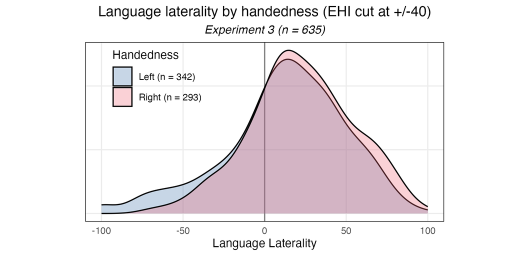

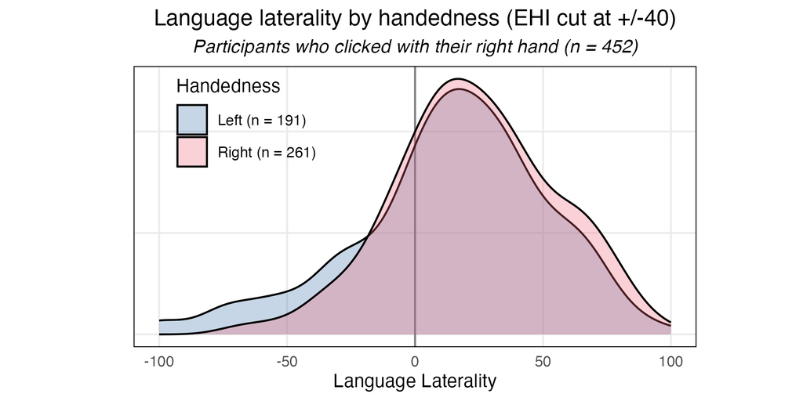

## Percentage REA/LEA ~ handedness

Language laterality distribution (cut at +/-10)

| handedness | ear_advantage | n | pct |
| --- | --- | --- | --- |
| Left | LEA | 78 | 22.807 |
| Left | REA | 199 | 58.187 |
| Left | none | 65 | 19.006 |
| Mixed | LEA | 16 | 16.162 |
| Mixed | REA | 66 | 66.667 |
| Mixed | none | 17 | 17.172 |
| Right | LEA | 44 | 15.017 |
| Right | REA | 188 | 64.164 |
| Right | none | 61 | 20.819 |

## Continuous handedness (exploratory)

### All language laterality

Do we find an interaction of field x level x handedness (continuous EHI score), when dichotic listening (continuous) is included in the model?

#### Stats

`rt_model_ehi <- lmer( rt ~ field*level*ehi*DL_lat*clickhand + (1 | subject) )`

Field by level by handedness (cont.) interaction (RT)<sup>1</sup>

Compare effect estimate to zero with emmeans()<sup>1</sup>

| field_consec | level_consec | estimate<sup>2</sup> | SE | df<sup>3</sup> | lower.CL<sup>4</sup> | upper.CL<sup>4</sup> | t.ratio | p.value<sup>5</sup> |
| --- | --- | --- | --- | --- | --- | --- | --- | --- |
| RVF - LVF | Global - Local | 0.134 | 0.041 | 87,058.214 | 0.053 | 0.216 | 3.234 | .001 |

<sup>1</sup> Model: field * level * ehi * DL_lat * clickhand + (1|subject) + (1|shape)  
<sup>2</sup> A positive number means local bias is stronger in RVF for right handers (as predicted by AAH), in ms per EHI unit (-100 to 100). Multiply this value by 200 to get the estimated difference in LVF global bias for strong left vs. right handers.  
<sup>3</sup> Z-approximation  
<sup>4</sup> Confidence level: 95  
<sup>5</sup> Two-sided

Experiment 3: Field by EHI (by Level) (RT)

Compare effect estimate to zero with emmeans()

| contrast | level | estimate<sup>1</sup> | SE | df<sup>2</sup> | lower.CL<sup>3</sup> | upper.CL<sup>3</sup> | t.ratio | p.value<sup>4</sup> |
| --- | --- | --- | --- | --- | --- | --- | --- | --- |
| LVF - RVF | Local | 0.135 | 0.03 | 87,058.774 | 0.077 | 0.193 | 4.543 | <.0001 |
| LVF - RVF | Global | 0.001 | 0.029 | 87,056.894 | −0.056 | 0.058 | 0.028 | .978 |

<sup>1</sup> A positive number means global bias is stronger in LVF for right handers (as predicted by AAH), in ms per EHI unit (-100 to 100). Multiply this value by 200 to get the estimated difference in LVF global bias for strong left vs. right handers.  
<sup>2</sup> Z-approximation  
<sup>3</sup> Confidence level: 95  
<sup>4</sup> Two-sided

### Within REA

Do we find an interaction of field x level x handedness (continuous EHI score), when analysis is limited to participants with REA (DL > 10)?

#### Stats

`rt_model_ehi <- lmer( rt ~ field*level*ehi + (1 | subject) )`

Model: rt ~ field * level * ehi + (1|subject)

REA only: Field by level by handedness (cont.) interaction (RT)<sup>1</sup>

Compare effect estimate to zero with emmeans()<sup>1</sup>

| field_consec | level_consec | estimate<sup>2</sup> | SE | df<sup>3</sup> | lower.CL<sup>4</sup> | upper.CL<sup>4</sup> | t.ratio | p.value<sup>5</sup> |
| --- | --- | --- | --- | --- | --- | --- | --- | --- |
| RVF - LVF | Global - Local | 0.105 | 0.045 | 53,742.104 | 0.017 | 0.193 | 2.344 | .019 |

<sup>1</sup> Model: field * level * ehi + (1|subject)  
<sup>2</sup> A positive number means local bias is stronger in RVF for right handers (as predicted by AAH), in ms per EHI unit (-100 to 100). Multiply this value by 200 to get the estimated difference in LVF global bias for strong left vs. right handers.  
<sup>3</sup> Z-approximation  
<sup>4</sup> Confidence level: 95  
<sup>5</sup> Two-sided

REA only: Field by level interaction by handedness (cont.; RT)<sup>1</sup>

Compare effect estimate to zero with emmeans()<sup>1</sup>

| contrast | estimate<sup>2</sup> | SE | df<sup>3</sup> | lower.CL<sup>4</sup> | upper.CL<sup>4</sup> | t.ratio | p.value<sup>5</sup> |
| --- | --- | --- | --- | --- | --- | --- | --- |
| LVF Local - RVF Local | 0.134 | 0.032 | 53,742.543 | 0.052 | 0.217 | 4.18 | .0002 |
| LVF Global - RVF Global | 0.029 | 0.031 | 53,741.523 | −0.051 | 0.109 | 0.94 | .783 |

<sup>1</sup> Model: field * level * ehi + (1|subject)  
<sup>2</sup> A positive number means more RVF bias for right handers, in ms per EHI unit (-100 to 100). Multiply by 200 to get the difference in ms between strong left and right handers  
<sup>3</sup> Z-approximation  
<sup>4</sup> Confidence level: 95%  
<sup>5</sup> Two-sided

## Categorical handedness (exploratory, EHI +/-40)

### All language laterality

#### Stats

Reaction time is modeled as a linear effect of field, level, and handedness, using data from every target-present trial with a “go” response:  
`lmer( rt ~ field*level*handedness*D_lat*clickhand + (1 | subject) )`

| handedness | n |
| --- | --- |
| Left | 277 |
| Right | 232 |

Field by level by handedness interaction (RT)<sup>1</sup>

Compare effect estimate to zero with emmeans()<sup>1</sup>

| field_consec | level_consec | handedness_consec | estimate<sup>2</sup> | SE | df<sup>3</sup> | lower.CL<sup>4</sup> | upper.CL<sup>4</sup> | t.ratio | p.value<sup>5</sup> |
| --- | --- | --- | --- | --- | --- | --- | --- | --- | --- |
| LVF - RVF | Local - Global | Right - Left | 37.907 | 9.087 | 60,263.63 | 20.097 | 55.717 | 4.172 | <.0001 |

<sup>1</sup> Model (yes clickhand): field * level * handedness * ear_advantage * clickhand + (1|subject) + (1|shape)  
<sup>2</sup> A positive number means RVF local bias is stronger in right handers (as predicted by AAH)  
<sup>3</sup> Z-approximation  
<sup>4</sup> Confidence level: 95%  
<sup>5</sup> Two-sided

LVF global bias by handedness bin (RT)<sup>1</sup>

| field_consec | level_consec | handedness | estimate<sup>2</sup> | SE | df<sup>3</sup> | lower.CL<sup>4</sup> | upper.CL<sup>4</sup> | t.ratio | p.value<sup>5</sup> |
| --- | --- | --- | --- | --- | --- | --- | --- | --- | --- |
| LVF - RVF | Local - Global | Left | 17.286 | 5.409 | 60,263.175 | 6.685 | 27.887 | 3.196 | .001 |
| LVF - RVF | Local - Global | Right | 55.193 | 7.302 | 60,263.879 | 40.882 | 69.504 | 7.559 | <.0001 |

<sup>1</sup> Model (yes clickhand): field * level * handedness * ear_advantage * clickhand + (1|subject) + (1|shape)  
<sup>2</sup> A positive number means global bias (faster RT for global)  
<sup>3</sup> Z-approximation  
<sup>4</sup> Confidence level: 95%  
<sup>5</sup> Two-sided, uncorrected

Effect of handedness on hemifield bias, by level (RT)<sup>1</sup>

| field_consec | handedness_consec | level | estimate<sup>2</sup> | SE | df<sup>3</sup> | lower.CL<sup>4</sup> | upper.CL<sup>4</sup> | t.ratio | p.value<sup>5</sup> |
| --- | --- | --- | --- | --- | --- | --- | --- | --- | --- |
| LVF - RVF | Right - Left | Global | −12.977 | 6.326 | 60,262.355 | −25.376 | −0.578 | −2.051 | .04 |
| LVF - RVF | Right - Left | Local | 24.93 | 6.522 | 60,264.462 | 12.146 | 37.714 | 3.822 | .0001 |

<sup>1</sup> Model (yes clickhand): field * level * handedness * ear_advantage * clickhand + (1|subject) + (1|shape)  
<sup>2</sup> A positive number means more RVF bias for right handers  
<sup>3</sup> Z-approximation  
<sup>4</sup> Confidence level: 95%  
<sup>5</sup> Two-sided, uncorrected

Hemifield bias by level by handedness bin (RT)<sup>1</sup>

| contrast | handedness | level | estimate<sup>2</sup> | SE | df<sup>3</sup> | lower.CL<sup>4</sup> | upper.CL<sup>4</sup> | t.ratio | p.value<sup>5</sup> |
| --- | --- | --- | --- | --- | --- | --- | --- | --- | --- |
| LVF - RVF | Left | Global | −23.226 | 3.771 | 60,262.639 | −30.618 | −15.835 | −6.159 | <.0001 |
| LVF - RVF | Left | Local | −5.941 | 3.877 | 60,263.381 | −13.539 | 1.658 | −1.532 | .125 |
| LVF - RVF | Right | Global | −36.204 | 5.079 | 60,262.201 | −46.158 | −26.249 | −7.128 | <.0001 |
| LVF - RVF | Right | Local | 18.989 | 5.245 | 60,265.065 | 8.709 | 29.27 | 3.62 | .0003 |

<sup>1</sup> Model (yes clickhand): field * level * handedness * ear_advantage * clickhand + (1|subject) + (1|shape)  
<sup>2</sup> A positive number means global bias (faster RT for global)  
<sup>3</sup> Z-approximation  
<sup>4</sup> Confidence level: 95%  
<sup>5</sup> Two-sided, uncorrected

#### Plots

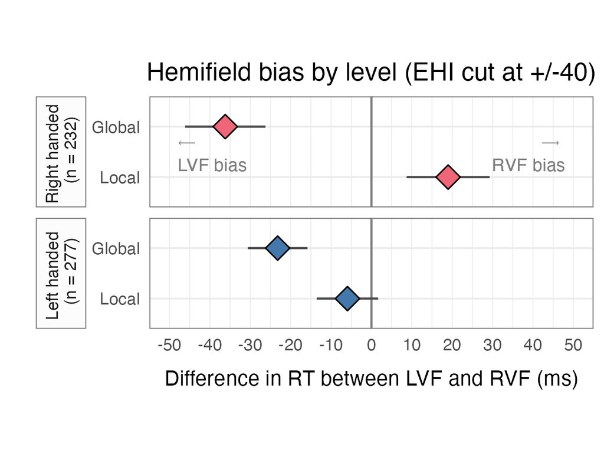

## Within REA

#### Stats

Reaction time is modeled as a linear effect of field, level, and handedness, using data from every target-present trial with a “go” response:  
`lmer( rt ~ field*level*handedness + (1 | subject) )`

| handedness | n |
| --- | --- |
| Left | 199 |
| Right | 188 |

REA only: Field by level by handedness interaction (RT)<sup>1</sup>

Compare effect estimate to zero with emmeans()<sup>1</sup>

| field_consec | level_consec | handedness_consec | estimate<sup>2</sup> | SE | df<sup>3</sup> | lower.CL<sup>4</sup> | upper.CL<sup>4</sup> | t.ratio | p.value<sup>5</sup> |
| --- | --- | --- | --- | --- | --- | --- | --- | --- | --- |
| LVF - RVF | Local - Global | Right - Left | 16.194 | 7.645 | 45,904.998 | 1.21 | 31.178 | 2.118 | .034 |

<sup>1</sup> Model: field * level * handedness + (1|subject)  
<sup>2</sup> A positive number means RVF local bias is stronger in right handers (as predicted by AAH)  
<sup>3</sup> Z-approximation  
<sup>4</sup> Confidence level: 95%  
<sup>5</sup> Two-sided

REA only: LVF Global bias by handedness bin (RT)<sup>1</sup>

| field_consec | level_consec | handedness | estimate<sup>2</sup> | SE | df<sup>3</sup> | lower.CL<sup>4</sup> | upper.CL<sup>4</sup> | t.ratio | p.value<sup>5</sup> |
| --- | --- | --- | --- | --- | --- | --- | --- | --- | --- |
| LVF - RVF | Local - Global | Left | 29.757 | 5.321 | 45,904.994 | 19.328 | 40.186 | 5.593 | <.0001 |
| LVF - RVF | Local - Global | Right | 45.951 | 5.489 | 45,905.002 | 35.192 | 56.71 | 8.371 | <.0001 |

<sup>1</sup> Model: field * level * handedness + (1|subject)  
<sup>2</sup> A positive number means global bias (faster RT for global)  
<sup>3</sup> Z-approximation  
<sup>4</sup> Confidence level: 95%  
<sup>5</sup> Two-sided, uncorrected

REA only: Effect of handedness on hemifield bias, by level (RT)<sup>1</sup>

| field_consec | handedness_consec | level | estimate<sup>2</sup> | SE | df<sup>3</sup> | lower.CL<sup>4</sup> | upper.CL<sup>4</sup> | t.ratio | p.value<sup>5</sup> |
| --- | --- | --- | --- | --- | --- | --- | --- | --- | --- |
| LVF - RVF | Right - Left | Global | 3.728 | 5.331 | 45,904.437 | −6.72 | 14.176 | 0.699 | .484 |
| LVF - RVF | Right - Left | Local | 19.922 | 5.48 | 45,905.443 | 9.182 | 30.662 | 3.636 | .0003 |

<sup>1</sup> Model: field * level * handedness + (1|subject)  
<sup>2</sup> A positive number means more RVF bias for right handers  
<sup>3</sup> Z-approximation  
<sup>4</sup> Confidence level: 95%  
<sup>5</sup> Two-sided, uncorrected

REA only: Hemifield bias by level by handedness bin (RT)<sup>1</sup>

| contrast | handedness | level | estimate<sup>2</sup> | SE | df<sup>3</sup> | lower.CL<sup>4</sup> | upper.CL<sup>4</sup> | t.ratio | p.value<sup>5</sup> |
| --- | --- | --- | --- | --- | --- | --- | --- | --- | --- |
| LVF - RVF | Left | Global | −28.162 | 3.725 | 45,904.597 | −35.463 | −20.861 | −7.56 | <.0001 |
| LVF - RVF | Left | Local | 1.595 | 3.8 | 45,905.397 | −5.852 | 9.042 | 0.42 | .675 |
| LVF - RVF | Right | Global | −24.434 | 3.813 | 45,904.285 | −31.908 | −16.961 | −6.408 | <.0001 |
| LVF - RVF | Right | Local | 21.517 | 3.948 | 45,905.485 | 13.778 | 29.256 | 5.45 | <.0001 |

<sup>1</sup> Model: field * level * handedness + (1|subject)  
<sup>2</sup> A positive number means global bias (faster RT for global)  
<sup>3</sup> Z-approximation  
<sup>4</sup> Confidence level: 95%  
<sup>5</sup> Two-sided, uncorrected

## Categorical handedness (exploratory, EHI +/-100)

### All language laterality

#### Stats

Reaction time is modeled as a linear effect of field, level, and handedness, using data from every target-present trial with a “go” response:  
`lmer( rt ~ field*level*handedness*D_lat*clickhand + (1 | subject) )`

| handedness | n |
| --- | --- |
| Left | 99 |
| Right | 105 |

Field by level by handedness interaction (RT)<sup>1</sup>

Compare effect estimate to zero with emmeans()<sup>1</sup>

| field_consec | level_consec | handedness_consec | estimate<sup>2</sup> | SE | df<sup>3</sup> | lower.CL<sup>4</sup> | upper.CL<sup>4</sup> | t.ratio | p.value<sup>5</sup> |
| --- | --- | --- | --- | --- | --- | --- | --- | --- | --- |
| LVF - RVF | Local - Global | Right - Left | 25.978 | 15.464 | 24,021.522 | −4.333 | 56.289 | 1.68 | .093 |

<sup>1</sup> Model (yes clickhand): field * level * handedness_extremes * ear_advantage * clickhand + (1|subject) + (1|shape)  
<sup>2</sup> A positive number means RVF local bias is stronger in right handers (as predicted by AAH)  
<sup>3</sup> Z-approximation  
<sup>4</sup> Confidence level: 95%  
<sup>5</sup> Two-sided

LVF global bias by handedness bin (RT)<sup>1</sup>

| field_consec | level_consec | handedness | estimate<sup>2</sup> | SE | df<sup>3</sup> | lower.CL<sup>4</sup> | upper.CL<sup>4</sup> | t.ratio | p.value<sup>5</sup> |
| --- | --- | --- | --- | --- | --- | --- | --- | --- | --- |
| LVF - RVF | Local - Global | Left | 21.064 | 9.3 | 24,021.52 | 2.835 | 39.293 | 2.265 | .024 |
| LVF - RVF | Local - Global | Right | 47.042 | 12.355 | 24,021.53 | 22.825 | 71.258 | 3.808 | .0001 |

<sup>1</sup> Model (yes clickhand): field * level * handedness_extremes * ear_advantage * clickhand + (1|subject) + (1|shape)  
<sup>2</sup> A positive number means global bias (faster RT for global)  
<sup>3</sup> Z-approximation  
<sup>4</sup> Confidence level: 95%  
<sup>5</sup> Two-sided, uncorrected

Effect of handedness on hemifield bias, by level (RT)<sup>1</sup>

| field_consec | handedness_consec | level | estimate<sup>2</sup> | SE | df<sup>3</sup> | lower.CL<sup>4</sup> | upper.CL<sup>4</sup> | t.ratio | p.value<sup>5</sup> |
| --- | --- | --- | --- | --- | --- | --- | --- | --- | --- |
| LVF - RVF | Right - Left | Global | −13.819 | 10.719 | 24,021.121 | −34.829 | 7.19 | −1.289 | .197 |
| LVF - RVF | Right - Left | Local | 12.158 | 11.145 | 24,021.653 | −9.686 | 34.003 | 1.091 | .275 |

<sup>1</sup> Model (yes clickhand): field * level * handedness_extremes * ear_advantage * clickhand + (1|subject) + (1|shape)  
<sup>2</sup> A positive number means more RVF bias for right handers  
<sup>3</sup> Z-approximation  
<sup>4</sup> Confidence level: 95%  
<sup>5</sup> Two-sided, uncorrected

Hemifield bias by level by handedness bin (RT)<sup>1</sup>

| contrast | handedness | level | estimate<sup>2</sup> | SE | df<sup>3</sup> | lower.CL<sup>4</sup> | upper.CL<sup>4</sup> | t.ratio | p.value<sup>5</sup> |
| --- | --- | --- | --- | --- | --- | --- | --- | --- | --- |
| LVF - RVF | Left | Global | −25.988 | 6.447 | 24,021.246 | −38.625 | −13.352 | −4.031 | <.0001 |
| LVF - RVF | Left | Local | −4.925 | 6.702 | 24,021.525 | −18.061 | 8.212 | −0.735 | .462 |
| LVF - RVF | Right | Global | −39.808 | 8.563 | 24,021.052 | −56.593 | −23.023 | −4.649 | <.0001 |
| LVF - RVF | Right | Local | 7.234 | 8.904 | 24,021.751 | −10.219 | 24.687 | 0.812 | .417 |

<sup>1</sup> Model (yes clickhand): field * level * handedness_extremes * ear_advantage * clickhand + (1|subject) + (1|shape)  
<sup>2</sup> A positive number means global bias (faster RT for global)  
<sup>3</sup> Z-approximation  
<sup>4</sup> Confidence level: 95%  
<sup>5</sup> Two-sided, uncorrected

## Categorical language (exploratory, EHI +/-40)

#### Stats

Reaction time is modeled as a linear effect of field, level, and handedness, using data from every target-present trial with a “go” response:  
`lmer( rt ~ field*level*handedness*ear_advantage*clickhand + (1 | subject) )`

| handedness | n |
| --- | --- |
| Left | 277 |
| Right | 232 |

Field by level by language laterality interaction (RT)<sup>1</sup>

Compare effect estimate to zero with emmeans()<sup>1</sup>

| field_consec | level_consec | ear_advantage_consec | estimate<sup>2</sup> | SE | df<sup>3</sup> | lower.CL<sup>4</sup> | upper.CL<sup>4</sup> | t.ratio | p.value<sup>5</sup> |
| --- | --- | --- | --- | --- | --- | --- | --- | --- | --- |
| LVF - RVF | Local - Global | REA - LEA | 11.238 | 9.087 | 60,263.627 | −6.572 | 29.048 | 1.237 | .216 |

<sup>1</sup> Model (yes clickhand): field * level * handedness * ear_advantage * clickhand + (1|subject) + (1|shape)  
<sup>2</sup> A positive number means RVF local bias is stronger in right eared participants (as predicted by LAH)  
<sup>3</sup> Z-approximation  
<sup>4</sup> Confidence level: 95%  
<sup>5</sup> Two-sided

LVF global bias by language laterality bin (RT)<sup>1</sup>

| field_consec | level_consec | ear_advantage | estimate<sup>2</sup> | SE | df<sup>3</sup> | lower.CL<sup>4</sup> | upper.CL<sup>4</sup> | t.ratio | p.value<sup>5</sup> |
| --- | --- | --- | --- | --- | --- | --- | --- | --- | --- |
| LVF - RVF | Local - Global | LEA | 30.62 | 7.738 | 60,263.622 | 15.454 | 45.787 | 3.957 | <.0001 |
| LVF - RVF | Local - Global | REA | 41.858 | 4.763 | 60,263.645 | 32.522 | 51.194 | 8.788 | <.0001 |

<sup>1</sup> Model (yes clickhand): field * level * handedness * ear_advantage * clickhand + (1|subject) + (1|shape)  
<sup>2</sup> A positive number means global bias (faster RT for global)  
<sup>3</sup> Z-approximation  
<sup>4</sup> Confidence level: 95%  
<sup>5</sup> Two-sided, uncorrected

Effect of language laterality on hemifield bias, by level (RT)<sup>1</sup>

| field_consec | ear_advantage_consec | level | estimate<sup>2</sup> | SE | df<sup>3</sup> | lower.CL<sup>4</sup> | upper.CL<sup>4</sup> | t.ratio | p.value<sup>5</sup> |
| --- | --- | --- | --- | --- | --- | --- | --- | --- | --- |
| LVF - RVF | REA - LEA | Global | 1.696 | 6.326 | 60,262.353 | −10.703 | 14.094 | 0.268 | .789 |
| LVF - RVF | REA - LEA | Local | 12.933 | 6.522 | 60,264.461 | 0.15 | 25.717 | 1.983 | .047 |

<sup>1</sup> Model (yes clickhand): field * level * handedness * ear_advantage * clickhand + (1|subject) + (1|shape)  
<sup>2</sup> A positive number means more RVF bias for right handers  
<sup>3</sup> Z-approximation  
<sup>4</sup> Confidence level: 95%  
<sup>5</sup> Two-sided, uncorrected

Hemifield bias by level by language laterality bin (RT)<sup>1</sup>

| contrast | ear_advantage | level | estimate<sup>2</sup> | SE | df<sup>3</sup> | lower.CL<sup>4</sup> | upper.CL<sup>4</sup> | t.ratio | p.value<sup>5</sup> |
| --- | --- | --- | --- | --- | --- | --- | --- | --- | --- |
| LVF - RVF | LEA | Global | −30.563 | 5.385 | 60,262.282 | −41.118 | −20.008 | −5.675 | <.0001 |
| LVF - RVF | LEA | Local | 0.058 | 5.556 | 60,264.613 | −10.833 | 10.948 | 0.01 | .992 |
| LVF - RVF | REA | Global | −28.867 | 3.319 | 60,262.55 | −35.373 | −22.362 | −8.697 | <.0001 |
| LVF - RVF | REA | Local | 12.991 | 3.416 | 60,264.092 | 6.296 | 19.686 | 3.803 | .0001 |

<sup>1</sup> Model (yes clickhand): field * level * handedness * ear_advantage * clickhand + (1|subject) + (1|shape)  
<sup>2</sup> A positive number means global bias (faster RT for global)  
<sup>3</sup> Z-approximation  
<sup>4</sup> Confidence level: 95%  
<sup>5</sup> Two-sided, uncorrected

## Continuous language (exploratory)

`rt_model_ehi <- lmer( rt ~ field*level*ehi*DL_lat*clickhand + (1 | subject) )`

Field by level by language laterality (cont.) interaction (RT)<sup>1</sup>

Compare effect estimate to zero with emmeans()<sup>1</sup>

| field_consec | level_consec | estimate<sup>2</sup> | SE | df<sup>3</sup> | lower.CL<sup>4</sup> | upper.CL<sup>4</sup> | t.ratio | p.value<sup>5</sup> |
| --- | --- | --- | --- | --- | --- | --- | --- | --- |
| RVF - LVF | Global - Local | 0.16 | 0.094 | 87,058.179 | −0.025 | 0.345 | 1.694 | .09 |

<sup>1</sup> Model: field * level * ehi * DL_lat * clickhand + (1|subject) + (1|shape)  
<sup>2</sup> A positive number means local bias is stronger in RVF for right earers (as predicted by LAH), in ms per DL unit (-100 to 100). Multiply this value by 200 to get the estimated difference in LVF global bias for strong left vs. right earers.  
<sup>3</sup> Z-approximation  
<sup>4</sup> Confidence level: 95  
<sup>5</sup> Two-sided

Experiment 3: Field by language laterality (by Level) (RT)

Compare effect estimate to zero with emmeans()

| contrast | level | estimate<sup>1</sup> | SE | df<sup>2</sup> | lower.CL<sup>3</sup> | upper.CL<sup>3</sup> | t.ratio | p.value<sup>4</sup> |
| --- | --- | --- | --- | --- | --- | --- | --- | --- |
| LVF - RVF | Local | 0.212 | 0.068 | 87,059.369 | 0.079 | 0.345 | 3.122 | .002 |
| LVF - RVF | Global | 0.052 | 0.065 | 87,056.457 | −0.076 | 0.181 | 0.799 | .424 |

<sup>1</sup> A positive number means global bias is stronger in LVF for right earers (as predicted by LAH), in ms per DL unit (-100 to 100). Multiply this value by 200 to get the estimated difference in LVF global bias for strong left vs. right earers.  
<sup>2</sup> Z-approximation  
<sup>3</sup> Confidence level: 95  
<sup>4</sup> Two-sided